[figure not shown]

# Title: Transportation Problem

## Teacher: Dr. Shokri

### Student Name: Mohammadali Shakerdargah

### Student Number: 810196487

### Student Name: Behnam Moradkhani

### Student Number: 810196559

### Student Name: Sahand Divsalaar

### Student Number: 810196466

### Winter 2021

[figure not shown]

## Purpose:

```
 Electricity is the vital energy source in both industrial production manufacturing and people’s daily lives so the
 importance of electric power generation and transmission is beyond question. As a link between electric power generation
 and transmission, electric power dispatching decides the effective and healthy operation of the whole power grid.
 The automation and intelligence of electric power dispatching is a long time issue concerning power grids deserving
 thorough research.
```

## Abstract:

##### Main Refrence of this project: A New Approach to Solve Transportation Problems

##### This refrence is an article by Mollah Mesbahuddin Ahmed, Aminur Rahman Khan, Md. Sharif Uddin, Faruque Ahmed at Department of Mathematics, Jahangirnagar University, Dhaka, Bangladesh

```
The transportation problem is a special type of linear programming problem where the objetive consists in minimizing
transportation cost of a given commodity from a number of sources or origins (e.g. factory, manufacturing facility) to
a number of destinations (e.g. warehouse, store). Each source has a limited supply (i.e. maximum number of products that
can be sent from it) while each destination has a demand to be satisfied (i.e. minimum number of products that need to be
shipped to it). The cost of shipping from a source to a destination is directly proportional to the number of units
shipped.
Finding an initial basic feasible solution is the prime requirement to obtain an optimal solution for
the transportation problems.
```

## Sections

#### Section G: Resources

# Section A: Cities and Power Plants

### Cities:

We have used https://www.google.com/maps to find suitable cities for our project

[figure not shown]

### Power Plants:

We have used https://openinframap.org/ to find suitable plants for our project, the flow of finding a plant is shown below:

First we decie to consider a specific plant for our project, let us suppose we are considering this plant:

[figure not shown]

We would click on it and it derives us to https://www.openstreetmap.org/relation/8255414#map=17/49.76206/31.47092 which we would see:

[figure not shown]

And we would be able too closely look at the details.

# Section B: Distance Measurement

### First Approach

Using maps to clearify the exact distance between a city and plant.

[figure not shown]

And using it we will be abel to calculate the actual distance through the transportation.

we can even get some little interesting details in https://openinframap.org/stats about the distances.

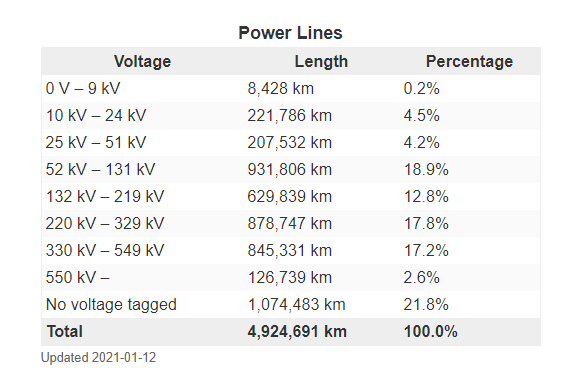

### Second Approach

Computing the algebric way, using 2 nodes like below:

[figure not shown]

we get the X-axis and Y-axis coordinates and calculate the distance like below:

[figure not shown]

# Section C: Generation of the Dataset

```python
import pandas as pd
import math
df_plant = pd.read_csv("Plant.csv")
df_city = pd.read_csv("City.csv")
```

```python
df_plant
```

|  | Num | Plant Name | XCoordinates | YCoordinates | Capacity | unit |
| --- | --- | --- | --- | --- | --- | --- |
| 0 | 1 | Rivne Nuclear Power Plant | 51.329582 | 25.893945 | 2835.000 | MW |
| 1 | 2 | Dtek Burshtynsʹka Tes | 49.208206 | 24.666646 | 2400.000 | MW |
| 2 | 3 | Dnister Pumped Storage Hydroelectric Power Plant | 48.512908 | 27.472271 | 972.000 | MW |
| 3 | 4 | Ladyzhynsʹka Tes | 48.707046 | 29.220161 | 1800.000 | MW |
| 4 | 5 | Khmelnitsky NPP | 50.302711 | 26.652174 | 2000.000 | MW |
| 5 | 6 | Офис ЗАО «Молдавская ГРЭС» | 46.624245 | 29.940757 | 2520.000 | MW |
| 6 | 7 | South Ukraine Nuclear Power Plant | 47.810694 | 31.220078 | 3000.000 | MW |
| 7 | 8 | Trypilʹsʹka Tes | 50.135479 | 30.750429 | 1800.000 | MW |
| 8 | 9 | Dtek Dniproenerho Kryvorizʹka Tes | 47.544376 | 33.657989 | 2820.000 | MW |
| 9 | 10 | Zaporizhzhya NPP | 47.506893 | 34.585066 | 6000.000 | MW |
| 10 | 11 | Zaporizhia TPP | 47.506885 | 34.632725 | 3650.000 | MW |
| 11 | 12 | Dnipro Hydroelectric Power Plant 1569MW | 47.872595 | 35.077295 | 1569.000 | MW |
| 12 | 13 | Prydniprovska TES | 48.403670 | 35.118077 | 1765.000 | MW |
| 13 | 14 | Kurskaya Atomnaya Stantsiya | 51.675369 | 35.604134 | 4000.000 | MW |
| 14 | 15 | Zmiivska TPP | 49.586602 | 36.524325 | 2200.000 | MW |
| 15 | 16 | Slovianska heat power station | 48.871800 | 37.764798 | 880.000 | MW |
| 16 | 17 | Kurakhove Power Station | 47.994517 | 37.244971 | 1527.000 | MW |
| 17 | 18 | Starobeshevsʹka Tes | 47.799276 | 38.004681 | 2010.000 | MW |
| 18 | 19 | Zuivska power station 1 | 48.033316 | 38.288793 | 1245.000 | MW |
| 19 | 20 | Vuhlehirsʹka Tes | 48.463305 | 38.202543 | 1200.000 | MW |
| 20 | 21 | Luhansʹka Tes | 48.748868 | 39.260921 | 1220.000 | MW |
| 21 | 22 | Novotsjerkassk kraftverk | 47.401503 | 40.231479 | 2258.000 | MW |
| 22 | 23 | Volga Hydroelectric Station | 48.826309 | 44.671912 | 2671.000 | MW |
| 23 | 24 | Dobrotvorsk power plant | 50.450264 | 30.523400 | 500.000 | MW |
| 24 | 25 | TETs-6 | 50.529908 | 30.665318 | 750.000 | MW |
| 25 | 26 | TETs-5 | 50.396993 | 30.567753 | 700.000 | MW |
| 26 | 27 | Kyiv1 | 50.611517 | 30.489995 | 235.500 | MW |
| 27 | 28 | Kyiv2 | 50.588537 | 30.512311 | 440.000 | MW |
| 28 | 29 | Kyiv3 | 50.529880 | 30.665286 | 750.000 | MW |
| 29 | 30 | Kyiv4 | 50.480801 | 30.511217 | 465.000 | MW |
| ... | ... | ... | ... | ... | ... | ... |
| 39 | 40 | Kamianske Hydroelectric Power Plant 1 | 48.546261 | 34.540379 | 352.000 | MW |
| 40 | 41 | Kamianske Hydroelectric Power Plant 2 | 48.536251 | 34.551553 | 246.400 | MW |
| 41 | 42 | Dnipro Solar Power Plant | 48.364818 | 35.182010 | 11.200 | MW |
| 42 | 43 | Nikopol Solar Power Plant | 47.686458 | 34.260702 | 246.154 | MW |
| 43 | 44 | Kakhovka Hydroelectric Power Plant | 46.776310 | 33.371798 | 351.000 | MW |
| 44 | 45 | Odesa Power Plant | 46.500839 | 30.721844 | 68.000 | MW |
| 45 | 46 | Mykolaiv Central Heating and Power Plant | 46.951036 | 31.986444 | 40.000 | MW |
| 46 | 47 | Tashlyk Pumped Storage Power Plant | 47.796472 | 31.180927 | 302.000 | MW |
| 47 | 48 | Oleksandrivsʹka Hes | 47.702942 | 31.253427 | 10.500 | MW |
| 48 | 49 | Voznesensk Solar Station | 47.572252 | 31.397288 | 29.300 | MW |
| 49 | 50 | Teploenerhetyk | 48.529386 | 32.245504 | 15.000 | MW |
| 50 | 51 | Rostovskaya Tets-2 | 47.217120 | 39.580189 | 200.000 | MW |
| 51 | 52 | Zuivska power station 2 | 48.021301 | 38.257004 | 12.000 | MW |
| 52 | 53 | Botiyevska wind power | 46.628387 | 35.736123 | 200.000 | MW |
| 53 | 54 | Simferopol Power Station 1 | 44.945505 | 34.221870 | 470.000 | MW |
| 54 | 55 | Simferopol Power Station 2 | 45.021198 | 34.035412 | 100.000 | MW |
| 55 | 56 | Simferopol Power Station 3 | 44.956752 | 33.931586 | 105.600 | MW |
| 56 | 57 | Sakskaya Tets | 45.136444 | 33.551382 | 149.400 | MW |
| 57 | 58 | Ohotnikovo Solar Station | 45.287113 | 33.599581 | 82.650 | MW |
| 58 | 59 | Solnechnaya elektrostantsiya "Mityaevo" | 45.238114 | 33.673529 | 31.550 | MW |
| 59 | 60 | Sevastopol Power Station | 44.555469 | 33.601208 | 470.000 | MW |
| 60 | 61 | Vladyslavivka Solar Power Plant | 45.148608 | 35.419657 | 110.000 | MW |
| 61 | 62 | Smolenskaya Aes, Filial Oao "Kontsern "Rosener... | 54.165940 | 33.233305 | 3000.000 | MW |
| 62 | 63 | Minsk 4 power station | 53.872940 | 27.400717 | 1035.000 | MW |
| 63 | 64 | CHP-3 Power Station | 53.879305 | 27.647836 | 542.000 | MW |
| 64 | 65 | Minskaya Tets-5 | 53.611270 | 27.947418 | 720.000 | MW |
| 65 | 66 | Mozyrskaja Tyec Filial Rup Gomel'Yenergo | 51.906186 | 29.313329 | 205.000 | MW |
| 66 | 67 | Svetlogorskaya Tets | 52.626362 | 29.769925 | 155.000 | MW |
| 67 | 68 | Chernihiv power plants | 51.457366 | 31.258265 | 210.000 | MW |
| 68 | 69 | Sumy Power Plant | 50.931324 | 34.818603 | 40.000 | MW |

69 rows × 6 columns

```python
df_city
```

|  | Num | City Name | XCoordinates | YCoordinates | Population | Consumption | Unit |
| --- | --- | --- | --- | --- | --- | --- | --- |
| 0 | 1 | Kyiv | 50.466430 | 30.510686 | 2884000 | 8652000 | kWh |
| 1 | 2 | Lviv | 49.842854 | 24.012233 | 721301 | 2163903 | kWh |
| 2 | 3 | Kharkiv | 50.007306 | 36.234318 | 1419000 | 4257000 | kWh |
| 3 | 4 | Poltava | 49.594235 | 34.550027 | 284942 | 854826 | kWh |
| 4 | 5 | Dnipro | 48.478603 | 35.033994 | 966400 | 2899200 | kWh |
| 5 | 6 | Odesa | 46.478803 | 30.733065 | 119702 | 359106 | kWh |
| 6 | 7 | Mykolaiv | 46.983594 | 31.985329 | 486268 | 1458804 | kWh |
| 7 | 8 | Kryvyi Rih | 47.917146 | 33.336270 | 634780 | 1904340 | kWh |
| 8 | 9 | Zaporizhzhia | 47.847850 | 35.196631 | 746749 | 2240247 | kWh |
| 9 | 10 | Donetsk | 47.999682 | 37.786918 | 918536 | 2755608 | kWh |
| 10 | 11 | Mariupol' | 47.128116 | 37.557921 | 446103 | 1338309 | kWh |

```python
#Distance Measurement
list_plant_Xcoordinates = df_plant["XCoordinates"].tolist()
list_plant_Ycoordinates = df_plant["YCoordinates"].tolist()
list_plant_Xcoordinates = list(map(float, list_plant_Xcoordinates))
list_plant_Ycoordinates = list(map(float, list_plant_Ycoordinates))

list_city_Xcoordinates = df_city["XCoordinates"].tolist()
list_city_Ycoordinates = df_city["YCoordinates"].tolist()
list_city_Xcoordinates = list(map(float, list_city_Xcoordinates))
list_city_Ycoordinates = list(map(float, list_city_Ycoordinates))
```

```python
def distanceCalculator(x1,y1,x2,y2):
    distance = math.sqrt(abs((x1-x2)**2 + (y1-y2)**2))
    return distance
```

```python
distance_allPlantsFromCities = []
for i in range(len(list_plant_Xcoordinates)):
    distance_PlantFromCities = []
    for j in range(len(list_city_Xcoordinates)):
        distance = distanceCalculator(list_plant_Xcoordinates[i], list_plant_Ycoordinates[1],
                                      list_city_Xcoordinates[j], list_city_Ycoordinates[j]);
        distance_PlantFromCities.append(distance)
    distance_allPlantsFromCities.append(distance_PlantFromCities)
distance_allPlantsFromCities
```

[output not shown]

[output cut: 704 more lines]

[output not shown]

## Section D:

### Defining Cost

To determine the cost function, we have to consider the loss of transmitting lines. Obviously, the more the distance, the more the electrical resistance of the line and the more the loss! To obtain a valid cost function we use the distance of transmitting lines and the transmitted power from sources to cities. Cost of using each line will be related to the length of line in a linear way like below:

[figure not shown]

```python
costs = []
max_dist = max(distance_PlantFromCities)
for i in range(len(distance_allPlantsFromCities)):
    cost_plant_to_city = []
    for j in range(len(distance_allPlantsFromCities[0])):
        cost = ((distance_allPlantsFromCities[i][j])/max_dist)/3
        cost_plant_to_city.append(cost)
    costs.append(cost_plant_to_city)
```

## Section E:

### Solution & Code

In this notation, c_ij is the cost of the line between source i (1≤i≤69) and city j (1≤j≤11), and d_ij represents the distance between them. The value 3 in the denominator is assumed the number of the bundles of the lines. By means of the cost parameters obtained above, we can define the cost function:

[figure not shown]

In fact, this cost function is the sum of all our lines. x_ij is the optimizing variable or in other words, it is the transmitted power from source i to city j. Now we have to form our limits as constraints of the problem. We have three group of constraints:

[figure not shown]

1. The power reached to the city j must be equal to the consumption of the city:

[figure not shown]

1. Transmitted power cannot be negative:

[figure not shown]

it considers the city-plant order, so it starts with each colomn :

```
x11: city1 - plant1 with c11
x12: city1 - plant2 with c12
x13: city1 - plant3 with c13
...
xnm: city_n - plant_m with c_nm
```

So we will have this order for both our cost and variable

```python
import matplotlib.pyplot as plt
from pulp import *

capacity_plant = df_plant["Capacity"].tolist()
powerConsumption_city = df_city["Consumption"].tolist()

edge_1D = []
for i in range(len(capacity_plant)):
        edge_1D.append((0,capacity_plant[i]))

cost_1D = []
for j in range(len(powerConsumption_city)): #reason of 'j' is that we are getting it vertically from 'costs'.
    for i in range(len(capacity_plant)):
        cost_1D.append(costs[i][j])

demand_1D = []
for i in range(len(powerConsumption_city)):
        demand_1D.append(powerConsumption_city[i]/1000)

variables = []
for j in range(len(powerConsumption_city)):
    variable_ofEachcity = []
    for i in range(len(capacity_plant)):
        variable_ofEachcity.append(LpVariable("x" + str(j+1)+ "_" + str(i+1), *edge_1D[i]))
    variables.append(variable_ofEachcity)

variables_1D = []
for j in range(len(powerConsumption_city)):
    for i in range(len(capacity_plant)):
        variables_1D.append(variables[j][i])

prob = LpProblem("Problem",LpMinimize)

prob += lpDot(cost_1D, variables_1D), "Costs"

sum_state_of_each_city = []
for j in range(len(powerConsumption_city)):
    sum_state_city = None
    for i in range(len(capacity_plant)):
        sum_state_city = sum_state_city + variables[j][i]
    sum_state_of_each_city.append(sum_state_city)

# len(sum_state_of_each_city[0])

prob += sum_state_of_each_city[0] == demand_1D[0]
prob += sum_state_of_each_city[1] == demand_1D[1]
prob += sum_state_of_each_city[2] == demand_1D[2]
prob += sum_state_of_each_city[3] == demand_1D[3]
prob += sum_state_of_each_city[4] == demand_1D[4]
prob += sum_state_of_each_city[5] == demand_1D[5]
prob += sum_state_of_each_city[6] == demand_1D[6]
prob += sum_state_of_each_city[7] == demand_1D[7]
prob += sum_state_of_each_city[8] == demand_1D[8]
prob += sum_state_of_each_city[9] == demand_1D[9]
prob += sum_state_of_each_city[10] == demand_1D[10]


status = prob.solve()

print(LpStatus[status])
print("Total Costs = ", value(prob.objective))

for j in range(len(powerConsumption_city)):
    for i in range(len(capacity_plant)):
        print("x"+ str(j) + "_" + str(i), value(variables[j][i]))

name =[]
for i in range(69):
    name.append(str(i+1))

variable_ofcity_1 = []
variable_ofcity_2 = []
variable_ofcity_3 = []
variable_ofcity_4 = []
variable_ofcity_5 = []
variable_ofcity_6 = []
variable_ofcity_7 = []
variable_ofcity_8 = []
variable_ofcity_9 = []
variable_ofcity_10 = []
variable_ofcity_11 = []

for i in range(len(capacity_plant)):
    variable_ofcity_1.append(variables[0][i])
    variable_ofcity_2.append(variables[1][i])
    variable_ofcity_3.append(variables[2][i])
    variable_ofcity_4.append(variables[3][i])
    variable_ofcity_5.append(variables[4][i])
    variable_ofcity_6.append(variables[5][i])
    variable_ofcity_7.append(variables[6][i])
    variable_ofcity_8.append(variables[7][i])
    variable_ofcity_9.append(variables[8][i])
    variable_ofcity_10.append(variables[9][i])
    variable_ofcity_11.append(variables[10][i])

value_variable_ofcity_1 = []
value_variable_ofcity_2 = []
value_variable_ofcity_3 = []
value_variable_ofcity_4 = []
value_variable_ofcity_5 = []
value_variable_ofcity_6 = []
value_variable_ofcity_7 = []
value_variable_ofcity_8 = []
value_variable_ofcity_9 = []
value_variable_ofcity_10 = []
value_variable_ofcity_11 = []

for i in range(len(variable_ofcity)):
    value_variable_ofcity_1.append(value(variable_ofcity_1[i]))
    value_variable_ofcity_2.append(value(variable_ofcity_2[i]))
    value_variable_ofcity_3.append(value(variable_ofcity_3[i]))
    value_variable_ofcity_4.append(value(variable_ofcity_4[i]))
    value_variable_ofcity_5.append(value(variable_ofcity_5[i]))
    value_variable_ofcity_6.append(value(variable_ofcity_6[i]))
    value_variable_ofcity_7.append(value(variable_ofcity_7[i]))
    value_variable_ofcity_8.append(value(variable_ofcity_8[i]))
    value_variable_ofcity_9.append(value(variable_ofcity_9[i]))
    value_variable_ofcity_10.append(value(variable_ofcity_10[i]))
    value_variable_ofcity_11.append(value(variable_ofcity_11[i]))
```

```
Optimal
Total Costs =  6104.180156270382
x0_0 0.0
x0_1 0.0
x0_2 0.0
x0_3 0.0
x0_4 2000.0
x0_5 0.0
x0_6 0.0
x0_7 1451.5
x0_8 0.0
x0_9 0.0
x0_10 0.0
x0_11 0.0
x0_12 0.0
x0_13 0.0
x0_14 0.0
x0_15 0.0
x0_16 0.0
x0_17 0.0
x0_18 0.0
x0_19 0.0
x0_20 0.0
x0_21 0.0
x0_22 0.0
x0_23 500.0
x0_24 750.0
x0_25 700.0
x0_26 235.5
x0_27 440.0
x0_28 750.0
x0_29 465.0
x0_30 160.0
x0_31 700.0
x0_32 500.0
x0_33 0.0
x0_34 0.0
x0_35 0.0
x0_36 0.0
x0_37 0.0
```

[output cut: 706 more lines]

```
x10_54 0.0
x10_55 0.0
x10_56 0.0
x10_57 0.0
x10_58 0.0
x10_59 0.0
x10_60 0.0
x10_61 0.0
x10_62 0.0
x10_63 0.0
x10_64 0.0
x10_65 0.0
x10_66 0.0
x10_67 0.0
x10_68 0.0
```

```
<BarContainer object of 69 artists>
```

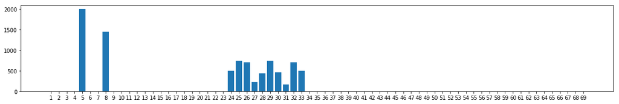

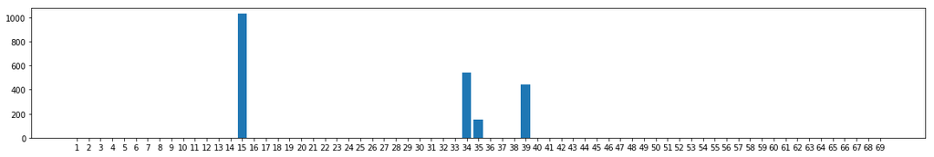

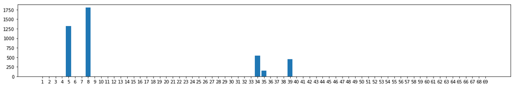

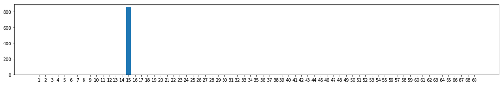

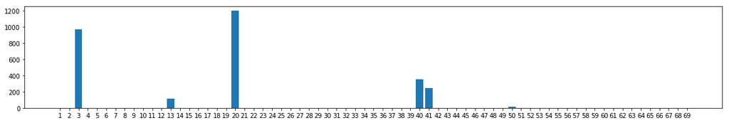

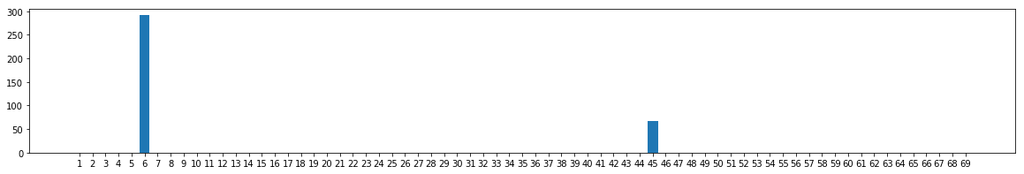

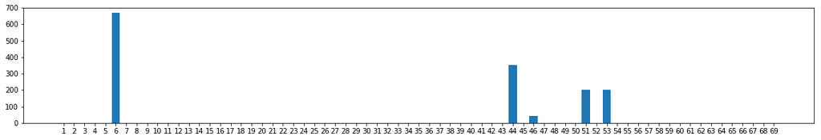

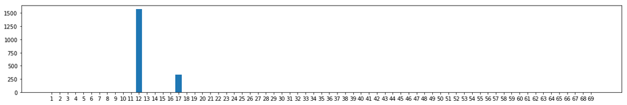

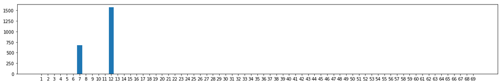

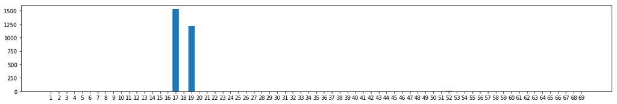

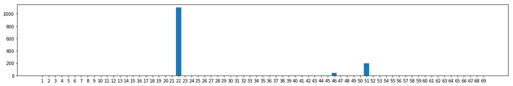

```python
plt.figure(figsize=(20, 3))
plt.bar(name, value_variable_ofcity_1)
plt.figure(figsize=(20, 3))
plt.bar(name, value_variable_ofcity_2)
plt.figure(figsize=(20, 3))
plt.bar(name, value_variable_ofcity_3)
plt.figure(figsize=(20, 3))
plt.bar(name, value_variable_ofcity_4)
plt.figure(figsize=(20, 3))
plt.bar(name, value_variable_ofcity_5)
plt.figure(figsize=(20, 3))
plt.bar(name, value_variable_ofcity_6)
plt.figure(figsize=(20, 3))
plt.bar(name, value_variable_ofcity_7)
plt.figure(figsize=(20, 3))
plt.bar(name, value_variable_ofcity_8)
plt.figure(figsize=(20, 3))
plt.bar(name, value_variable_ofcity_9)
plt.figure(figsize=(20, 3))
plt.bar(name, value_variable_ofcity_10)
plt.figure(figsize=(20, 3))
plt.bar(name, value_variable_ofcity_11)
```

## Section G:

### Main Resources:

#### [1] https://scipbook.readthedocs.io/en/latest/intro.html , https://towardsdatascience.com

#### [2] A New Approach to Solve Transportation Problems by Mollah Mesbahuddin Ahmed, Aminur Rahman Khan, Md. Sharif Uddin, Faruque Ahmed at Department of Mathematics, Jahangirnagar University, Dhaka, Bangladesh

### Other Resources:

#### [3] Hitchcock, F.L. (1941) The Distribution of a Product from Several Sources to Numerous Localities. Journal of Mathematics and Physics, 20, 224-230. http://dx.doi.org/10.1002/sapm1941201224

#### [4] Dantzig, G.B. (1951) Application of the Simplex Method to a Transportation Problem, Activity Analysis of Production and Allocation. In: Koopmans, T.C., Ed., John Wiley and Sons, New York, 359-373.

#### [5] Charnes, A., Cooper, W.W. and Henderson, A. (1953) An Introduction to Linear Programming. John Wiley & Sons, New York.

#### [6] Rashid, A., Ahmed, S.S. and Uddin, Md.S. (2013) Development of a New Heuristic for Improvement of Initial Basic Feasible Solution of a Balanced Transportation Problem. Jahangirnagar University Journal of Mathematics and Mathematical Sciences, 28, 105-112.